# Metadata over Voetafdruk landgebruik en biodiversiteit - landen en sectoren

2024-10-01T10:00:00

## Technische informatie

- **Periodiciteit**: vijfjaarlijks
- **Volgende update**: 2027
- **Databereik**: 2010 - 2019

## Databron

- **Producent**: VITO i.s.m. het Instituut voor Natuur- en Bosonderzoek (INBO)
- **Dataset**: het economische basismodel bestaat uit een combinatie van twee multiregionale input-outputmodellen (Exiobase versie 3.8.2 en EORA), gekoppeld aan het Vlaamse input-outputmodel. Verschillende druk- en impactmodellen brengen de milieu-impact van de bedrijfstakken uit het economische basismodel in kaart. Het achtergronddocument (Alaerts, Stevens, en Christis 2023) geeft een uitgebreide toelichting over de gebruikte methodes.
- **Gegevensinzameling**: We combineren deze drie input-outputmodellen om zo veel mogelijk landen van impact, en verantwoordelijke sectoren en productgroepen te kunnen onderscheiden. De basisdata van de multiregionale input-outputmodellen komen voort uit internationale statistieken zoals FAOSTAT en UN Comtrade. Het Vlaamse model wordt opgemaakt door het Federaal Planbureau en in een tijdreeks gezet door VITO. De tabellen die de milieu-impact per bedrijfstak weergeven (de milieu-extensietabellen), steunen op diverse druk- en impactmodellen (zie berekeningswijze) en voor ruimtelijk expliciete gegevens o.a. ook op een wereldwijde landgebruikskaart.

## Berekeningswijze

Zie ook (Alaerts, Stevens, en Christis 2023).

**Financiële stromen als basis**

In de hele set van voetafdrukindicatoren (voetafdruk biomassagebruik, voetafdruk landgebruik en biodiversiteit, voetafdruk ontbossing en koolstofuitstoot in de tropen) kiezen we voor één methode om het verband te leggen tussen grondstofstromen en hun impact: **monetaire input-outputmodellering**. Een multiregionaal monetair input-outputmodel (MRIO) modelleert handelsstromen tussen verschillende bedrijfstakken (bv. veeteelt, vervaardiging van diervoeders, vleesverwerking, textiel- en lederproductie …) uit verschillende landen. Daarvoor gebruikt het tabellen die de financiële stromen van en naar die bedrijfstakken in beeld brengen. Die stromen worden verbonden met producten en diensten bestemd voor eindconsumptie (bv. X% van de output van een bedrijfstak gaat naar vleesproducten, Y% naar oliën en vetten, Z% naar chemische producten, Q% naar bouwwerken …). Ze worden ook gekoppeld aan milieu-extensietabellen die de milieu-impact per eenheid output van een bedrijfstak weergeven (bv. X ton CO2-eq of X ha akkerland per euro output). Op basis van al die informatie kan onder meer de druk en impact die de totale consumptie van een land in andere landen veroorzaakt, achterhaald worden.

**Consumptie, productie, export, economie: waar gaat het om?**

Figuur 1 toont het verband tussen de begrippen die in de bespreking aan bod komen.

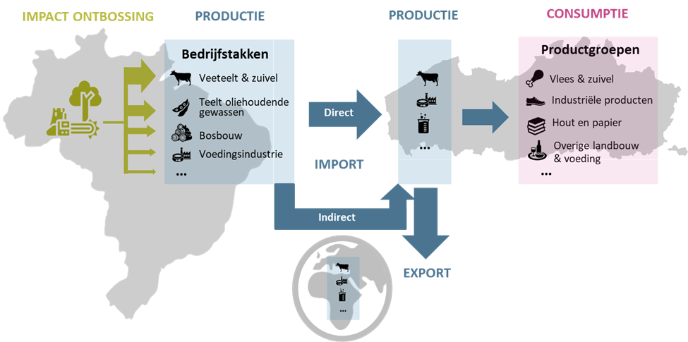

De Vlaamse **consumptie** omvat de vraag naar goederen en diensten door huishoudens, vzw’s en overheden, maar ook investeringen in vaste activa zoals woongelegenheden, infrastructuur en machines, en de veranderingen in voorraden van bedrijven. De Vlaamse **export** omvat alle uitvoer van intermediaire en afgewerkte producten. Goederen die louter door Vlaanderen getransporteerd worden, of in Vlaanderen verhandeld, maar niet verwerkt worden, tellen niet mee. De Vlaamse **economie** is de som van onze Vlaamse consumptie en onze productie voor export.

We tonen voor elke impactcategorie (hier landgebruik en verlies aan soorten):

- de **landen waar de impact** veroorzaakt door Vlaamse consumptie en export zich situeert,
- de verantwoordelijke **bedrijfstakken in die landen** en
- de **productgroepen** die wij **in Vlaanderen consumeren of exporteren** en die aan de basis liggen van de impact.

De impact die per **bedrijfstak in een land** getoond wordt, omvat enkel de lokale impact van die bedrijfstak, **niet** de impact van de **ganse voorketen**. Zo omvat de impact van de Braziliaanse voedingsindustrie op het landgebruik in Brazilië (voor Vlaamse consumptie) enkel de impact van de verwerking van voeding, niet de impact van de productie van grondstoffen (groenten, granen, fruit…). De impact van de productie van de grondstoffen zit vervat onder de bedrijfstakken “productie van groenten, fruit en noten”, “productie van granen” … in Brazilië of andere landen van herkomst. Voor de bedrijfstak veeteelt en zuivel telt de productie van veevoer (gras, granen, oliehoudende gewassen…) wel mee in de impact als dat veevoer op het bedrijf zelf geproduceerd wordt.

**Landgebruik**

De impact op het landgebruik wordt in de voorgestelde indicator opgedeeld in akkerland, grasland en bosland (land voor bosbouw). De data komen uit de milieu-extensietabellen van Exiobase en EORA, en zijn gecorrigeerd op basis van productiedata uit FAOSTAT (cf. (Cabernard en Pfister 2021)). De cijfers voor Vlaanderen worden gecorrigeerd o.b.v. de landgebruiksdata uit StatBel. **Niet-productieve gronden en ongebruikte graslanden en bossen** zijn in de mate van het mogelijke uit de dataset gefilterd. De kwaliteit van de achterliggende data verschilt echter sterk van land tot land (zie (Alaerts, Stevens, en Christis 2023), Bijlage 2.1 Landgebruik). Bossen hebben een **kroonbedekking van > 10%** (cf. de FAO-definitie van bos). Gebruikte bossen zijn gekoppeld aan de bosbouwsector, graslanden aan drie veeteelt- en zuivelsectoren en akkerlanden aan de negen bijbehorende akkerbouwsectoren uit Exiobase.

De methode maakt een **strikt onderscheid tussen gebruik als bosland en als grasland**, terwijl beide gebruiken in de praktijk vaak overlappen: in savannegebieden kan vee bv. grazen op plekken met een kroonbedekking boven de 10%.

Voor de impact van de **bosbouwsector** geldt een gelijkaardige nuance (zie (Alaerts, Stevens, en Christis 2023), Bijlage 2.1 Landgebruik). In landen met een **grote, extensief gebruikte bosoppervlakte** zoals Rusland en Congo-Kinshasa is onze (bos)landvoetafdruk hoog. Op basis van de wereldwijd beschikbare data is het onderscheid tussen bos met extensief of zonder bosbouwgebruik (houtoogst) vaak moeilijk te maken.

De impact van dat intensieve of extensieve gebruik hangt bovendien af van de **draagkracht van het ecosysteem**. Die draagkracht komt ***niet aan bod** in de indicator voor landgebruik. Hij wordt voor een deel in rekening gebracht in de indicator over het verlies aan soorten door landgebruik.

**Verlies aan soorten door landgebruik**

De impact van het landgebruik op de biodiversiteit wordt uitgedrukt in mondiale PDF (*potentially disappeared fraction of species*), een maat voor het potentieel uitsterven van soorten op wereldschaal als gevolg van ons landgebruik ((Chaudhary e.a. 2015), (Chaudhary en Kastner 2016); (Verones e.a. 2017),(Verones e.a. 2020)). De maat is gebaseerd op data uit **vijf verschillende taxonomische groepen** (zoogdieren, vogels, amfibieën, reptielen en planten) en houdt rekening met de **kwetsbaarheid van soorten**. Ze brengt het mogelijke verlies van soorten op lange termijn in kaart als het landgebruik van het bestudeerde jaar gelijk blijft. Ze berekent het verschil tussen de huidige situatie en een natuurlijke referentiesituatie uit het verleden. Ze legt daarmee de nadruk op gebieden die **in het verleden** al grote biodiversiteitsverliezen leden (bv. akkers die reeds decennia of eeuwen in landbouwgebruik zijn, leggen op die plaats een hypotheek op de ontwikkeling van soortenrijkdom) en waar herstel van de natuurlijke situatie potentieel een grote biodiversiteitswinst oplevert.

Data over het potentieel wereldwijd soortenverlies per eenheid van landgebruik (akkerland met jaarlijkse of permanente gewassen, grasland, intensief of extensief bosland) komen uit de studie van (Chaudhary en Kastner 2016). Ze worden gecombineerd met de bijbehorende landoppervlaktes uit FAOSTAT. Die landoppervlaktes worden op hun beurt toegewezen aan de relevante economische sectoren uit Exiobase (cf. (Cabernard en Pfister 2021)).

De indicator focust op het **biodiversiteitsverlies op wereldschaal**. Op dat niveau betekent het verdwijnen van soorten en ecosystemen vaak een onherstelbaar verlies aan (genetische) informatie en functies. Het **lokaal of regionaal verlies** aan (niet-wereldwijd bedreigde) soorten krijgt een lager gewicht, maar kan wel een belangrijke rol spelen in lokale ecologische processen. Die lokale impact komt slechts beperkt in beeld. **Taxonomische groepen zoals insecten, bacteriën en fungi**, die het merendeel van de wereldwijde soortenrijkdom uitmaken, zitten niet vervat in de resultaten. Ook **andere vormen van biodiversiteitsverlies**, zoals veranderingen in de omvang van populaties, komen niet in beeld.

## Opmerkingen bij de gegevenskwaliteit en betrouwbaarheid

De gerapporteerde cijfers in de reeks van voetafdrukindicatoren verschillen van die uit het achtergrondrapport ((Alaerts, Stevens, en Christis 2023)), omdat het basismodel ondertussen enkele **aanpassingen en correcties** onderging. De belangrijkste wijzigingen zijn:

- Grondstoffen en producten die in Vlaanderen louter verhandeld worden voor export en hier geen verdere verwerking ondergaan (de “**wederuitvoer**”), worden niet meer meegeteld in de impact van onze export. Ook goederen die enkel door Vlaanderen getransporteerd worden, zonder eigendom te worden van een Vlaams bedrijf (de “**doorvoer**”), tellen niet mee in de exportcijfers. Dit om afstemming te verzekeren met de andere voetafdrukindicatoren van de Vlaamse overheid (koolstofvoetafdruk, materialenvoetafdruk). In het achtergrondrapport ((Alaerts, Stevens, en Christis 2023)) werd enkel de doorvoer niet tot de export gerekend, de wederuitvoer telde wel mee. De aanpassing heeft een grote invloed op de gerapporteerde impact van onze Vlaamse export.
- Ook de verdeling van de Vlaamse consumptie over de verschillende **productgroepen** werd aangepast om afstemming te verzekeren met de andere voetafdrukindicatoren van de Vlaamse overheid (koolstofvoetafdruk, materialenvoetafdruk). De voetafdrukindicatoren in deze fiche brengen louter de impact van verhandelde biomassastromen in beeld. Een opdeling van de consumptie per type biomassastroom (bv. dierlijke voeding, niet-dierlijke voeding, energieproducten, houtproducten…) zou de interpretatie van de resultaten kunnen vereenvoudigen. Bij toekomstige updates wordt de haalbaarheid van zo’n indeling nagegaan.
- De data voor het gebruik van gas en elektriciteit uit het Vlaamse input-outputmodel werden verfijnd en in aparte categorieën gerapporteerd.
- Enkele fouten in de data van het multiregionale model Exiobase 3.8.2 werden gecorrigeerd.
- De datareeks 2010-2016 werd toegevoegd. De reeks 2010-2016 is berekend op basis van het interregionaal input-outputmodel 2010 en de updates daarvan, de reeks 2015-2019 is berekend op basis van het interregionaal input-outputmodel 2015 en de updates daarvan. Tussen beide periodes is de structuur van het economische basismodel gewijzigd, de resultaten van beide periodes zijn daarom niet zomaar te vergelijken.

We gebruiken **recente modellen en de best beschikbare data**, die in verschillende gevalstudies op hun kwaliteit en nauwkeurigheid getest zijn. Op vele schattingen zit echter een **grote onzekerheid**, die **inherent** is aan werken met multinationale databanken van diverse origine en met complexe impact-ketens. Om de set van voetafdruk-indicatoren uit het experimentele stadium te lichten, is verder onderzoek naar hun betrouwbaarheid noodzakelijk. Welk effect heeft het gebruik van een ander type input-outputmodel bijvoorbeeld op de resultaten? En wat als een ander landgebruiks- of biodiversiteitsmodel gehanteerd wordt?

De resultaten vormen een goede basis om **grootteordes** mee te geven en algemene verhoudingen tussen (grote groepen van) landen en sectoren af te leiden. Ze kunnen helpen om het **bewustzijn** rond onze externe impact te vergroten en om **hotspots** van impact aan te duiden voor verdere actie of onderzoek. De grote onzekerheid op de basisdata en op de modellen maakt de indicatoren **niet geschikt** om uitspraken te doen over de impact van **meer specifieke** bedrijfstakken en producten. Enkele beperkingen die eigen zijn aan (financiële) input-outputmodellering beïnvloeden de interpretatie van de resultaten, o.a.:

- Het model **bundelt diverse sectoren per land in grote groepen**. Dat geldt zeker voor diverse activiteiten die van land- en bosbouw afhankelijk zijn, en die de basis vormen van de voetafdrukberekeningen in deze indicatorenset. Zo worden uiteenlopende oorzaken samengevoegd die aan de basis kunnen liggen van onze impact. Dat maakt het soms moeilijk om verschillen tussen indicatoren en tussen opeenvolgende jaren in detail te duiden.
- De gebruikte input-outputmodellen hebben een financiële basis. De geregistreerde milieu-impact wordt (her)verdeeld over verschillende sectoren op basis van de **grootte van financiële stromen** tussen die sectoren. Financiële stromen zijn niet altijd representatief voor verhandelde hoeveelheden goederen, noch voor hun milieu-impact. Prijsfluctuaties kunnen een grote invloed hebben op het resultaat.
- **Verschillen in de structuur** van het Vlaamse input-outputmodel en de internationale modellen laten voorlopig niet toe om de impact van Vlaanderen rechtstreeks te vergelijken met de impact van België en met die van andere landen.
- De indicatoren zijn steeds te interpreteren als **schattingen van het “risico op impact”**, niet als exacte cijfers. Ze rapporteren hoofdzakelijk data op **landniveau**. De exacte locatie van de productie en impact is met deze gegevens niet te achterhalen. De impact is daarom steeds gebaseerd op **gemiddelde productiepraktijken** in een land. In welke mate de goederen die Vlaanderen invoert en consumeert afkomstig zijn van duurzame productiepraktijken of ontbossingsvrije herkomsten, is niet uit de data af te leiden. Dat maakt het moeilijk om het **effect van specifiek Vlaams beleid apart** te onderzoeken.
- Omdat de betrouwbaarheid van de modelresultaten voorlopig niet ingeschat kan worden, is het niet mogelijk om na te gaan of de verschillen tussen opeenvolgende jaren te wijten zijn aan reële veranderingen van de impact op het terrein of aan schommelingen die eigen zijn aan het model, bijvoorbeeld prijsschommelingen in verschillende sectoren. Dat maakt het model momenteel **niet geschikt om trends (op korte termijn) op te volgen**.

Elke eventuele **update** van de voorgestelde indicatoren moet rekening houden met de huidige **vorderingen in het onderzoek en het beleid** ter zake. Zo is het bijvoorbeeld van belang dat de indicatoren voor ontbossing dezelfde definitie voor bos hanteren als het beleid dat de ontbossing wil aanpakken. Op Europees en internationaal niveau wordt gezocht naar afstemming tussen verschillende mogelijke methodes en modellen. Kant-en-klare modellen die de grootste beperkingen van de modellen die we in dit rapport gebruiken, aanpakken, zijn momenteel nog niet beschikbaar. Maar verschillende internationale wetenschappelijke consortia werken hard aan verbeteringen.

De voorgestelde indicatoren vormen een **eerste stap** om een beter zicht te krijgen op de impact van de Vlaamse economie op de biodiversiteit in de wereld. Ze zijn nog experimenteel en vormen een basis om op verder te bouwen. **Aanvullende indicatoren** zijn nodig om bijvoorbeeld een gedetailleerder beeld te krijgen van belangrijke goederenstromen of om acties die ondernomen worden om onze impact aan te pakken beter op te volgen.

## Download

**Broncode indicator**: voetafdruk_landgebruik_land_sector.Rmd

**Broncode metadata**: metadata_voetafdruk_land_sector.Rmd

Gegevens om de figuren te reproduceren.

| Beschrijving | Gegevens | Metadata |
| --- | --- | --- |
| data_sankey_landgebruik_cons | data_sankey_landgebruik_cons.csv | data_sankey_landgebruik_cons.yml |
| data_sankey_landgebruik_exp | data_sankey_landgebruik_exp.csv | data_sankey_landgebruik_exp.yml |
| data_sankey_soorten_cons | data_sankey_soorten_cons.csv | data_sankey_soorten_cons.yml |
| data_sankey_soorten_exp | data_sankey_soorten_exp.csv | data_sankey_soorten_exp.yml |
| data_trend_land_cons | data_trend_land_cons.csv | data_trend_land_cons.yml |
| data_trend_land_exp | data_trend_land_exp.csv | data_trend_land_exp.yml |
| data_trend_land_tot | data_trend_land_tot.csv | data_trend_land_tot.yml |
| data_trend_pg_cons | data_trend_pg_cons.csv | data_trend_pg_cons.yml |
| data_trend_pg_exp | data_trend_pg_exp.csv | data_trend_pg_exp.yml |
| data_trend_pg_tot | data_trend_pg_tot.csv | data_trend_pg_tot.yml |
| links_sankey_landgebruik_cons | links_sankey_landgebruik_cons.csv | links_sankey_landgebruik_cons.yml |
| links_sankey_landgebruik_exp | links_sankey_landgebruik_exp.csv | links_sankey_landgebruik_exp.yml |
| links_sankey_soorten_cons | links_sankey_soorten_cons.csv | links_sankey_soorten_cons.yml |
| links_sankey_soorten_exp | links_sankey_soorten_exp.csv | links_sankey_soorten_exp.yml |
| nodes_sankey_landgebruik_cons | nodes_sankey_landgebruik_cons.csv | nodes_sankey_landgebruik_cons.yml |
| nodes_sankey_landgebruik_exp | nodes_sankey_landgebruik_exp.csv | nodes_sankey_landgebruik_exp.yml |
| nodes_sankey_soorten_cons | nodes_sankey_soorten_cons.csv | nodes_sankey_soorten_cons.yml |
| nodes_sankey_soorten_exp | nodes_sankey_soorten_exp.csv | nodes_sankey_soorten_exp.yml |
| tabel1_bedrijfstakken_productgroepen | Tabel1_bedrijfstakken_productgroepen.csv | Tabel1_bedrijfstakken_productgroepen.yml |

## Referenties

Alaerts, Katrijn, Maarten Stevens, en Maarten Christis. 2023. ‘De impact van Vlaanderen op de biodiversiteit in de wereld: op zoek naar indicatoren.’ België: Instituut voor Natuur- en Bosonderzoek.

Cabernard, Livia, en Stephan Pfister. 2021. ‘A highly resolved MRIO database for analyzing environmental footprints and Green Economy Progress’. *Science of The Total Environment* 755 (februari): 142587. https://doi.org/10.1016/j.scitotenv.2020.142587.

Chaudhary, Abhishek, en Thomas Kastner. 2016. ‘Land use biodiversity impacts embodied in international food trade’. *Global Environmental Change* 38 (mei): 195–204. https://doi.org/10.1016/j.gloenvcha.2016.03.013.

Chaudhary, Abhishek, Francesca Verones, Laura de Baan, en Stefanie Hellweg. 2015. ‘Quantifying Land Use Impacts on Biodiversity: Combining Species–Area Models and Vulnerability Indicators’. *Environmental Science & Technology* 49 (16): 9987–95. https://doi.org/10.1021/acs.est.5b02507.

Verones, Francesca, Stefanie Hellweg, Assumpció Antón, Ligia B. Azevedo, Abhishek Chaudhary, Nuno Cosme, Stefano Cucurachi, e.a. 2020. ‘LC-IMPACT: A regionalized life cycle damage assessment method’. *Journal of Industrial Ecology* 24 (6): 1201–19. https://doi.org/10.1111/jiec.13018.

Verones, Francesca, Daniel Moran, Konstantin Stadler, Keiichiro Kanemoto, en Richard Wood. 2017. ‘Resource footprints and their ecosystem consequences’. *Scientific Reports* 7 (januari): 40743. https://doi.org/10.1038/srep40743.